# Estimation of the impact of the Solar eclipse of June 10, 2021 on the solar radiation and PV power production in Europe

### supplementary material to the data paper sumitted to SEJ

Jens Thieler{2}, Yves-Marie Saint-Drenan(1), Carmen Köhler(3), Laurent Dubus(4), Lionel Ménard(1), Philippe Blanc(1)

1 MINES ParisTech, PSL Research University, O.I.E. Centre Observation, Impacts, Energy, 06904 Sophia Antipolis, France 2 Deutscher Wetterdienst – Seewetteramt, Hamburg, Germany 3 P³R GmbH, Königswinter, Germany 4 RTE, Paris, France

### import of the needed libraries

```python
import netCDF4 as nc
import datetime as dt
import numpy as np
import matplotlib.pyplot as plt
```

### connexion to the Thredds server containing the data

```python
import netCDF4 as nc
thredds_url = 'http://tds.webservice-energy.org/thredds/dodsC/eclipse/'
filename='SolarEclipseEU_20210610_v2.nc'
data_nc = nc.Dataset(thredds_url+filename)
print(data_nc)
```

```
<class 'netCDF4._netCDF4.Dataset'>
root group (NETCDF3_CLASSIC data model, file format DAP2):
    comments:
    geospatial_lat_units: degrees_north
    geospatial_lon_units: degrees_east
    date_created: 2021-06-4
    Conventions: CF-1.6, ACDD-1.3
    creator_name: Jens Thieler (DWD)
    acknowledgement: DWD, Mines Paristech
    title: Dataset of relative visible area of the sun in percent during the solar eclipse of June the 10th, 2021
    summary: Relative visible area of the sun in percent during the solar eclipse of June the 10th, 2021 broadband and in the visible range
    abstract: Results of calculation of the relative visible area of the sun in percent during the solar eclipse of June the 10th, 2021 broadband and in the visible range
    keywords: solar eclipse; solar radiation; shadow; moon
    references: TBD
    institution: DWD; MINES ParisTech
    geospatial_lat_min: 26.1229
    geospatial_lat_max: 70.9998
    geospatial_lon_min: -34.2451
    geospatial_lon_max: 63.4678
    time_coverage_start: 10-Jun-2021 08:35:00
    time_coverage_end: 10-Jun-2021 12:35:00
    time_coverage_resolution: PT1M
    history:
    DODS_EXTRA.Unlimited_Dimension: time
    dimensions(sizes): time(241), lat(657), lon(665)
    variables(dimensions): int32 time(time), float64 latitude(lon, lat), float64 longitude(lon, lat), int32 CountryID(lon, lat), float32 rel_sun_vis(time, lon, lat), float32 rel_sun_si2(time, lon, lat), float32 SEL(time, lon, lat), float32 SAZ(time, lon, lat), float32 Gcs_max_control(time, lon, lat)…
    groups:
```

### extraction of a time series for a given point

```python
ilat,ilon=307,197

lat=data_nc["latitude"][ilon,ilat]
lon=data_nc["longitude"][ilon,ilat]

time=[dt.datetime(2000,1,1,0,0)+dt.timedelta(seconds=int(x)) for x in data_nc["time"][:].data]
rel_sun_si2=data_nc["rel_sun_si2"][:,ilon,ilat].data
Gcs_max_control=data_nc["Gcs_max_control"][:,ilon,ilat].data
Gcs_max_eclipse=data_nc["Gcs_max_eclipse"][:,ilon,ilat].data
```

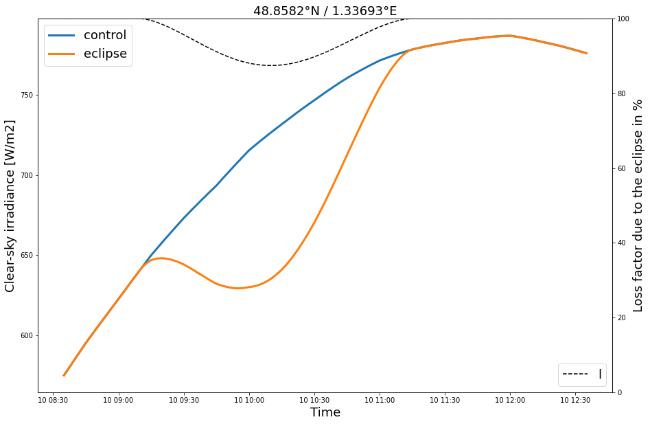

```python
plt.figure(figsize=(15,10))

ax1=plt.subplot()

ax1.plot(time,Gcs_max_control,time,Gcs_max_eclipse,lw=3)
plt.xlabel('Time',fontsize=18)
plt.ylabel('Clear-sky irradiance [W/m2]',fontsize=18)
ax1.legend(('control','eclipse'),fontsize=18,loc=0)

ax2=ax1.twinx()

ax2.plot(time,rel_sun_si2,'k--')
plt.ylim((0,100))
plt.title('{}°N / {}°E'.format(lat,lon),fontsize=18)
plt.xlabel('Time',fontsize=18)
plt.ylabel('Loss factor due to the eclipse in %',fontsize=18)
ax2.legend('loss factor',fontsize=18,loc=4)
```

### extraction of map for a given time step

```python
iTime=120
lat=data_nc["latitude"][:,:]
lon=data_nc["longitude"][:,:]
time=nc.num2date(data_nc["time"][iTime],units=data_nc["time"].units)
rel_sun_vis=data_nc["rel_sun_vis"][iTime,:,:].data
Gcs_max_control=data_nc["Gcs_max_control"][iTime,:,:].data
Gcs_max_eclipse=data_nc["Gcs_max_eclipse"][iTime,:,:].data
```

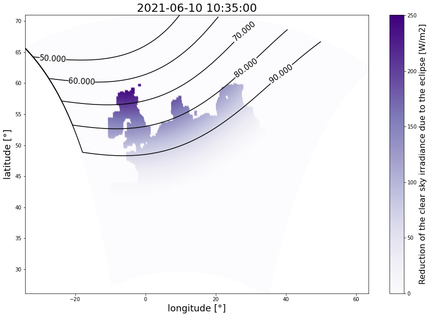

```python
plt.figure(figsize=(15,10))
contour=plt.contour(lon,lat,rel_sun_vis,levels=[50,60,70,80,90],colors='k')
plt.clabel(contour,inline=True,fontsize=15)

shd=plt.scatter(lon,lat,c=Gcs_max_control-Gcs_max_eclipse,cmap='Purples')
cbar = plt.colorbar(shd)
cbar.set_label('Reduction of the clear sky irradiance due to the eclipse [W/m2]',fontsize=16)
plt.xlabel('longitude [°]',fontsize=18)
plt.ylabel('latitude [°]',fontsize=18)
plt.title(time,fontsize=22)
```

### Maximal absolute reduction of the clear sky irradiance due to the eclipse in each of the EU countries

```python
time=[dt.datetime(2000,1,1,0,0)+dt.timedelta(seconds=int(x)) for x in data_nc["time"][:].data]

CountryID=['FR','HR','HU','AL','AT','BE','BG','CH','CY','CZ','DE','DK','EE','EL','IE','ES','FI',\
         'IS','PT','RO','RS','SE','SI','SK','TR','UK','NO','IT','LI','LT','LU','LV','ME','MK',\
         'MT','NL','PL']
CountryID=data_nc["CountryID"][:,:]

Time_MaxCSRed=[]
Val_MaxCSRed=[]

for iTime,Time in enumerate(time):
    print(iTime)
    Gcs_max_control=data_nc["Gcs_max_control"][iTime,:,:].data
    Gcs_max_eclipse=data_nc["Gcs_max_eclipse"][iTime,:,:].data
    dGcs=Gcs_max_control-Gcs_max_eclipse

    for iCnty,CTY in enumerate(CountryID):
        tAvgGcsRed=np.mean(dGcs[CountryID==iCnty+1])

        if iTime==0:
            Time_MaxCSRed.append(Time)
            Val_MaxCSRed.append(tAvgGcsRed)
        else:
            if (Val_MaxCSRed[iCnty]<tAvgGcsRed):
                Time_MaxCSRed[iCnty]=Time
                Val_MaxCSRed[iCnty]=tAvgGcsRed
```

```
0
1
2
3
4
5
6
7
8
9
10
11
12
13
14
15
16
17
18
19
20
21
22
23
24
25
26
27
28
29
30
31
32
33
34
35
36
37
38
39
```

[output cut: 186 more lines]

```
226
227
228
229
230
231
232
233
234
235
236
237
238
239
240
```

### Preparation of the raster to display the maximal impact of the eclipse per country

```python
lat=data_nc["latitude"][:,:]
lon=data_nc["longitude"][:,:]

MapCNTYRed=np.zeros(lon.shape)
for iCnty,CTY in enumerate(CountryID):

    if iCnty==0:
        CountryLat=np.mean(lat[MapCNTYID==iCnty+1])
        CountryLon=np.mean(lon[MapCNTYID==iCnty+1])
    else:
        CountryLat=np.append(CountryLat,np.mean(lat[MapCNTYID==iCnty+1]))
        CountryLon=np.append(CountryLon,np.mean(lon[MapCNTYID==iCnty+1]))

    if not np.isin(CTY,['NO','IS','SE','FI','TR']):
        MapCNTYRed[MapCNTYID==iCnty+1]=Val_MaxCSRed[iCnty]
```

### plot of the results

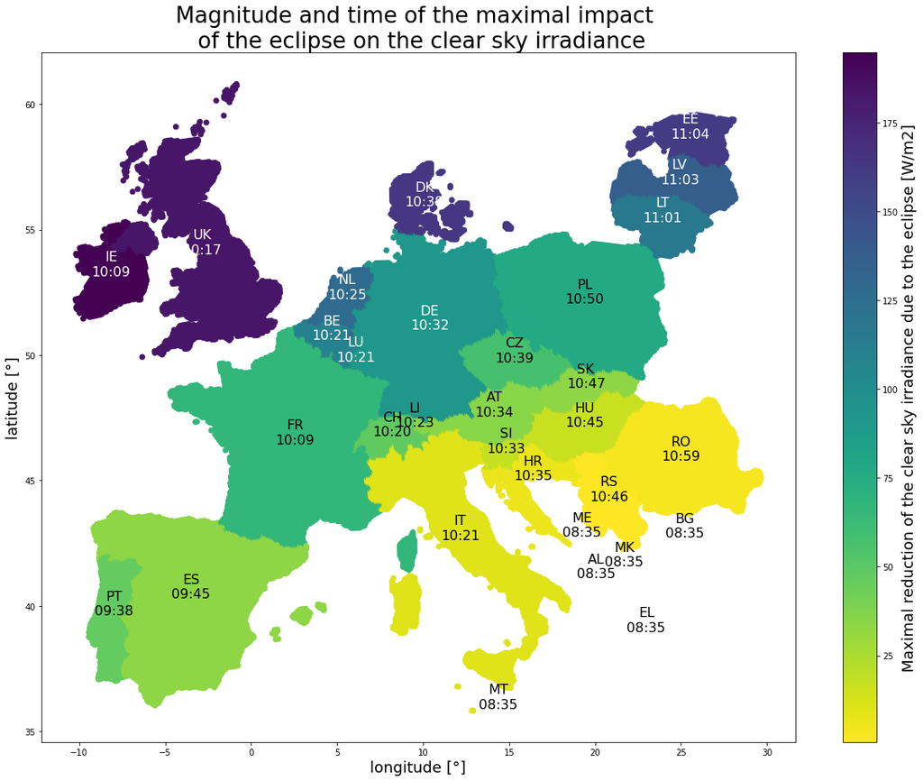

```python
plt.figure(figsize=(20,15))
ixSC=(MapCNTYID>0) & (MapCNTYRed>0)
orig_map=plt.cm.get_cmap('viridis')
reversed_map = orig_map.reversed()

CLR=plt.scatter(lon[ixSC],lat[ixSC],c=MapCNTYRed[ixSC],cmap=reversed_map)
for iCnty,CTY in enumerate(CountryID):
    Str=CTY+"\n"+Time_MaxCSRed[iCnty].strftime("%H:%M")
    if (CountryLat[iCnty]<60) & (CountryLon[iCnty]<30):
        if Val_MaxCSRed[iCnty]<80:
            plt.text(CountryLon[iCnty],CountryLat[iCnty],Str,ha='center',fontsize=16)
        else:
            plt.text(CountryLon[iCnty],CountryLat[iCnty],Str,color='w',ha='center',fontsize=16)
cbar = plt.colorbar(CLR)
cbar.set_label('Maximal reduction of the clear sky irradiance due to the eclipse [W/m2]',fontsize=18)
plt.xlabel('longitude [°]',fontsize=18)
plt.ylabel('latitude [°]',fontsize=18)
plt.title('Magnitude and time of the maximal impact \n of the eclipse on the clear sky irradiance',\
          fontsize=26)
```

### Time series of the country averaged effect of the eclipse for a selected number of countries

```python
time=[dt.datetime(2000,1,1,0,0)+dt.timedelta(seconds=int(x)) for x in data_nc["time"][:].data]

CountryID=['FR','HR','HU','AL','AT','BE','BG','CH','CY','CZ','DE','DK','EE','EL','IE','ES','FI',\
         'IS','PT','RO','RS','SE','SI','SK','TR','UK','NO','IT','LI','LT','LU','LV','ME','MK',\
         'MT','NL','PL']
MapCNTYID=data_nc["CountryID"][:,:]

SelectedCNTY=['IE', 'UK', 'DK', 'EE' , 'FR', 'BE', 'DE', 'PL' , 'PT', 'ES', 'IT', 'RO']
AvgGcsControl=np.zeros((len(time),len(SelectedCNTY)))
AvgGcsEclipse=np.zeros((len(time),len(SelectedCNTY)))
for iTime,Time in enumerate(time):
    print(iTime)
    tGcsRef=data_nc["Gcs_max_control"][iTime,:,:].data
    tGcsEcl=data_nc["Gcs_max_eclipse"][iTime,:,:].data

    for iCNTY0,CNTY in enumerate(SelectedCNTY):

        for j,X in enumerate(CountryID):
            if CNTY==X:
                iCNTY=j

        for iCnty,CTY in enumerate(CountryID):
            AvgGcsControl[iTime,iCNTY0]=np.mean(tGcsRef[MapCNTYID==iCNTY+1])
            AvgGcsEclipse[iTime,iCNTY0]=np.mean(tGcsEcl[MapCNTYID==iCNTY+1])
```

```
0
1
2
3
4
5
6
7
8
9
10
11
12
13
14
15
16
17
18
19
20
21
22
23
24
25
26
27
28
29
30
31
32
33
34
35
36
37
38
39
```

[output cut: 186 more lines]

```
226
227
228
229
230
231
232
233
234
235
236
237
238
239
240
```

[output not shown]

### plot of the results

[figure not shown]

```python
from matplotlib.dates import DateFormatter

plt.figure(figsize=(20,18))

for iCNTY,CNTY in enumerate(SelectedCNTY):
    ax=plt.subplot(4,4,iCNTY+1)
    plt.plot(time,AvgGcsControl[:,iCNTY],time,AvgGcsEclipse[:,iCNTY])
    plt.legend(('control','eclipse'))
    plt.title(CNTY,fontsize=20)
    if iCNTY>=8:
        plt.xlabel('Time',fontsize=18)
    if np.isin(iCNTY,[0,4,8]):
        plt.ylabel('Clear sky irradiance\n [W/m2]',fontsize=18)
    ax.xaxis.set_major_formatter( DateFormatter("%H"))
```

### export of the results as csv data

```python
iCNTY=4

import csv


with open('eclipse'+SelectedCNTY[iCNTY]+'.csv', 'w', newline='') as csvfile:
    fieldnames = ['time', 'AvgGcsControl','AvgGcsEclipse']
    writer = csv.DictWriter(csvfile, fieldnames=fieldnames)
    writer.writeheader()
    for ii,tTime in enumerate(time):
        writer.writerow({'time': time[ii].strftime("%d-%m-%Y %H:%M"),\
                         'AvgGcsControl': AvgGcsControl[ii,iCNTY],\
                         'AvgGcsEclipse': AvgGcsEclipse[ii,iCNTY]})
```